# degrees of freedom (yet again)

“How can I calculate the degrees of freedom for effects in this GLMM?

This is a hard, and possibly impossible question in some cases. The GLMM FAQ has a [detailed discussion](https://bbolker.github.io/mixedmodels-misc/glmmFAQ.html#why-doesnt-lme4-display-denominator-degrees-of-freedomp-values-what-other-options-do-i-have). Short version:

- If you are fitting a LMM rather than a GLMM (i.e., Gaussian responses), then the Kenward-Roger and Satterthwaite approximations are available through the `lmerTest` or `pbkrtest` packages, `car::Anova()`, etc. (Most of these packages rely on a primary implementations in `pbkrtest`, at least for K-R.)
- Getting a reliable p-value (which is the main reason people want df in the first place) can be done via parametric or nonparametric bootstrapping (e.g. `pbkrtest` again).

What are your other options?

```r
## need this to get a bug-fix for simulating beta responses ...
remotes::install_github("glmmTMB/glmmTMB/glmmTMB",
                        ref = "simulate_new_init_fix")
library(glmmTMB)
library(parallel)
library(future.apply)
plan(multisession, workers = 4)
```

Simulate an example (details don’t really matter):

```r
data("sleepstudy", package = "lme4")
ss <- transform(sleepstudy,
                prop = simulate_new(
                    ~ 1 + Days + (1 + Days | Subject),
                    newdata = sleepstudy,
                    newparams = list(beta = c(-1, 0.1),
                                     theta = c(-1, -1, 0),
                                     betad = 10),
                    family = "beta_family",
                    seed = 101)[[1]])
m <- glmmTMB(prop ~ 1 + Days + ( 1 + Days | Subject),
             family = beta_family, data = ss)
```

Baseline coefficient matrix (with $Z$ statistics/tests):

```r
printCoefmat(cc <- coef(summary(m))$cond)
```

```
##              Estimate Std. Error  z value Pr(>|z|)
## (Intercept) -0.893587   0.060849 -14.6852   <2e-16 ***
## Days        -0.045797   0.081183  -0.5641   0.5727
## ---
## Signif. codes:  0 '***' 0.001 '**' 0.01 '*' 0.05 '.' 0.1 ' ' 1
```

You can use this code to use the ‘inner-outer’/‘within-between’ level-counting rules that are intended for classical balanced designs (and implemented in `nlme`: see details in the GLMM FAQ).

```r
source("https://bbolker.github.io/mixedmodels-misc/R/calcDenDF.R")
transform_coeftab <- function(x, ddf) {
    m <- match(names(ddf), rownames(x))
    if (any(is.na(m)) || length(setdiff(rownames(x), names(ddf)) > 0)) {
        stop("mismatch between rownames and ddf names")
    }
    val_col <- grep("z.*val", colnames(x), ignore.case = TRUE)
    pr_col <- grep("pr.*z", colnames(x), ignore.case = TRUE)
    colnames(x)[val_col] <- sub("z", "t", colnames(x)[val_col], ignore.case = TRUE)
    pr_name <- sub("z", "t",  colnames(x)[pr_col], ignore.case = TRUE)
    x[, pr_col] <- 2*pt(-abs(x[,val_col]), lower.tail = TRUE, df = ddf)
    ## easier way to insert a column?
    x <- cbind(x[, 1:(val_col-1)], ddf = ddf, x[, pr_col])
    colnames(x)[ncol(x)] <- pr_name
    return(x)
}
```

```r
print(ddf <- calcDenDF( fixed = ~ Days, random = ~Days | Subject, data = ss))
```

```
## (Intercept)        Days
##         162          16
```

```r
cc2 <- transform_coeftab(cc, ddf)
## would be nice to format ddf column as integer but I think printCoefmat()
##  is not quite flexible enough ... ?
printCoefmat(cc2)
```

```
##              Estimate Std. Error ddf Pr(>|t|)
## (Intercept) -0.893587   0.060849 162   <2e-16 ***
## Days        -0.045797   0.081183  16   0.5805
## ---
## Signif. codes:  0 '***' 0.001 '**' 0.01 '*' 0.05 '.' 0.1 ' ' 1
```

```r
## could parallelize, etc etc
## (future/furrr packages?)
m0 <- update(m, . ~ . - Days)
simfun <- function(progress = FALSE) {
    ## depends on i, pb, set externally (next chunk)
    if (progress) {
        i <<- i + 1
        setTxtProgressBar(pb, i)
    }
    dsim <- simulate(m0)[[1]]
    ## provide data explicitly for scoping reasons
    fit <- update(m, dsim ~ ., data = ss)
    cc <- coef(summary(fit))$cond
    cc["Days", "z value"]
}
```

```r
nsim <- 5e3
progress <- FALSE ## progress bar doesn't work well with parallelization
if (progress) {
    pb <- txtProgressBar(max = nsim, style = 3)
    i <- 0
}
set.seed(102)
## see https://www.jottr.org/2020/09/22/push-for-statistical-sound-rng/
system.time(
    vals <- future_replicate(nsim, simfun(FALSE),
                             future.packages = "glmmTMB",
                             future.seed = TRUE)
)
```

```
##    user  system elapsed
##  49.227   1.496 601.206
```

```r
t_fit <- MASS::fitdistr(vals, "t")
df_est <- t_fit$estimate[["df"]]
df_sd <- t_fit$sd[["df"]]
```

The estimate of `df` is 21 (with fairly wide CIs: ± 2 SE is [11, 31])

Confidence intervals on ddf from glmmTMB:

```r
tt <- TMB::sdreport(glmmTMB(vals ~ 1, family = t_family, data = NULL)$obj)
## estimates/SEs on log scale
ddf_est <- tt$par.fixed[["psi"]]
ddf_sd <- sqrt(diag(tt$cov.fixed)[["psi"]])
exp(ddf_est)  ## est
```

```
## [1] 23.79181
```

```r
## CIs:
exp(ddf_est+qnorm(c(0.025, 0.975))*ddf_sd)
```

```
## [1] 13.35140 42.39631
```

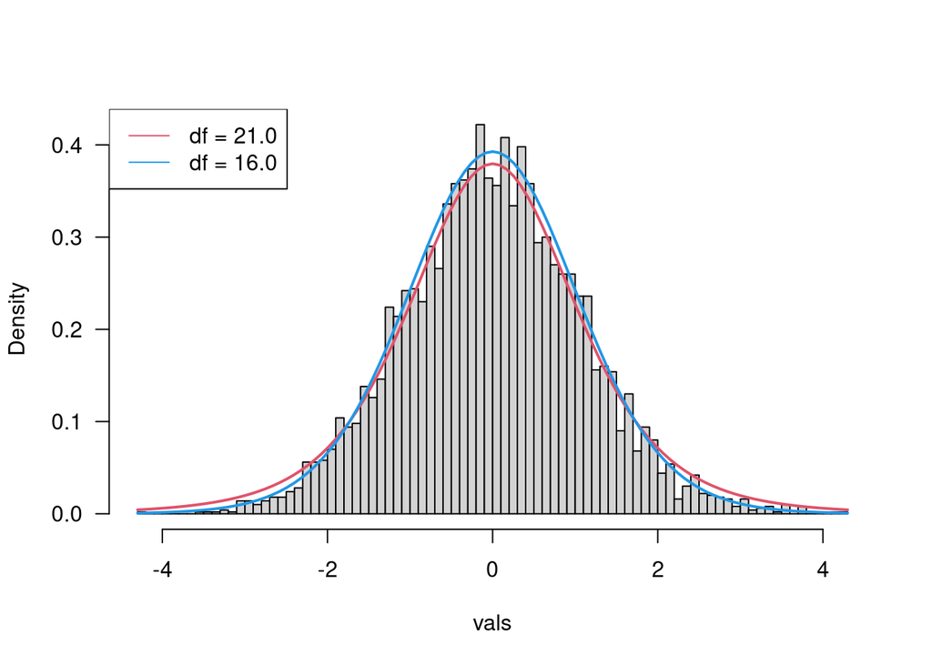

```r
par(las = 1)
hist(vals, breaks = 80, main = "", freq = FALSE)
curve(dt(x/t_fit$estimate[["s"]], df = df_sd), add = TRUE, col = 2, lwd = 2)
curve(dt(x/t_fit$estimate[["s"]], df = 16), add = TRUE, col = 4, lwd = 2)
legend("topleft",
       lty = 1,
       col = c(2,4),
       legend = sprintf("df = %1.1f", c(df_est, 16)))
```

**experimental** below here …

Alternatively, if we know the $\alpha$-level at which we want to test, we can specifically find the $t$ distribution with the correct tail area. (This should work but there’s something I’m not understanding right now …)

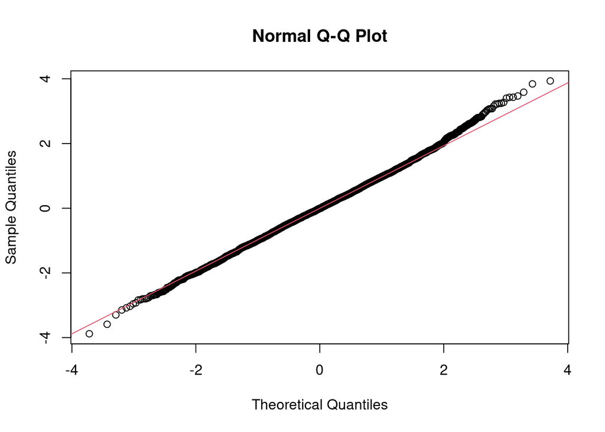

```r
qqnorm(scale(vals))
qqline(scale(vals), col  = 2)
```

definitely heavy-tailed … ?? missing something here ?? t-quantiles are considerably more extreme ??

df (16) fits the upper tail well but overcompensates in the lower tail …

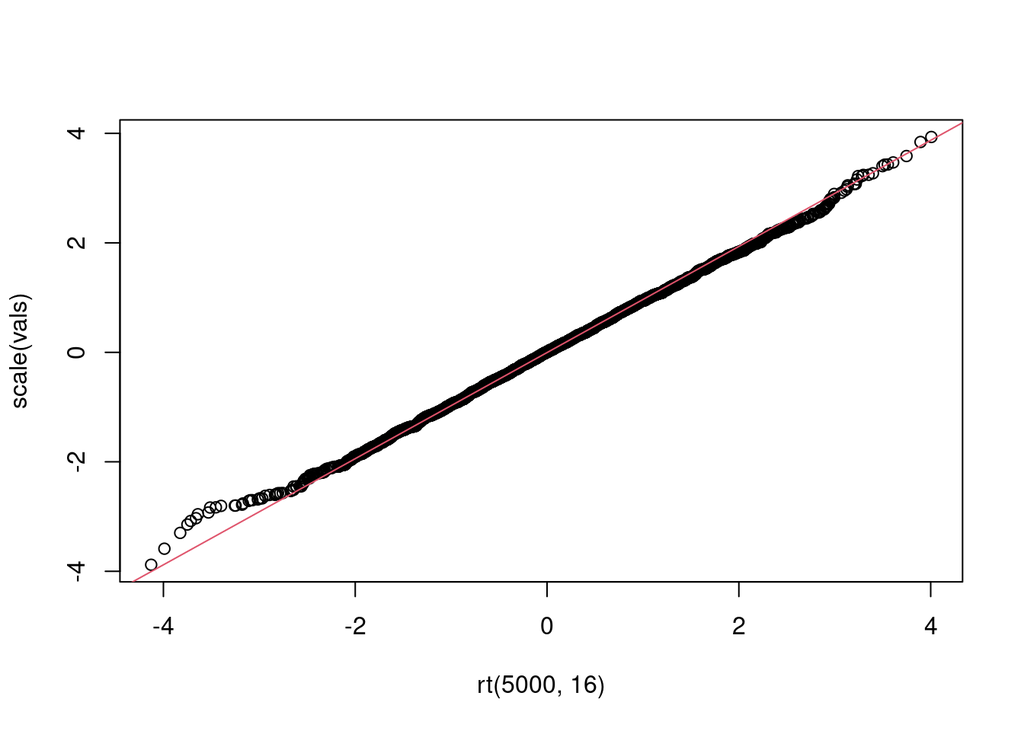

```r
qqplot(rt(5000, 16), scale(vals))
qqline(scale(vals), col  = 2)
```

```r
obs_q <- quantile(scale(vals), 0.05)
qnorm(0.05)
```

```
## [1] -1.644854
```

```r
qt(0.05, 16)
```

```
## [1] -1.745884
```

```r
quantile(scale(vals), 0.95)
```

```
##      95%
## 1.655733
```

```r
qt(0.95, 16)
```

```
## [1] 1.745884
```